# Overview

Dataset info

| Number of variables | 33 |
| --- | --- |
| Number of observations | 330000 |
| Total Missing (%) | 0.0% |
| Total size in memory | 83.1 MiB |
| Average record size in memory | 264.0 B |

Variables types

| Numeric | 21 |
| --- | --- |
| Categorical | 9 |
| Date | 0 |
| Text (Unique) | 0 |
| Rejected | 3 |

Warnings

- `anc_veh` has 70330 / 21.3% zeros
- `annee_permis` is highly correlated with `annee_naissance` (ρ = 0.99614) Rejected
- `codepostal` has a high cardinality: 23746 distinct values Warning
- `marque` has a high cardinality: 157 distinct values Warning
- `var10` has 7048 / 2.1% zeros
- `var11` is highly correlated with `anc_veh` (ρ = 0.999) Rejected
- `var12` is highly correlated with `kmage_annuel` (ρ = 0.90886) Rejected
- `var15` has 116228 / 35.2% zeros
- `var19` has 230464 / 69.8% zeros
- `var2` has 5538 / 1.7% zeros
- `var20` has 154706 / 46.9% zeros
- `var21` has 30921 / 9.4% zeros
- `var22` has 126690 / 38.4% zeros
- `var4` has 153696 / 46.6% zeros

# Variables

anc_veh  
Numeric

| Distinct count | 44 |
| --- | --- |
| Unique (%) | 0.0% |
| Missing (%) | 0.0% |
| Missing (n) | 0 |
| Infinite (%) | 0.0% |
| Infinite (n) | 0 |

| Mean | 16.206 |
| --- | --- |
| Minimum | 0 |
| Maximum | 99 |
| Zeros (%) | 21.3% |

Toggle details

Quantile statistics

| Minimum | 0 |
| --- | --- |
| 5-th percentile | 0 |
| Q1 | 1 |
| Median | 2 |
| Q3 | 31 |
| 95-th percentile | 99 |
| Maximum | 99 |
| Range | 99 |
| Interquartile range | 30 |

Descriptive statistics

| Standard deviation | 24.7 |
| --- | --- |
| Coef of variation | 1.5241 |
| Kurtosis | 4.2848 |
| Mean | 16.206 |
| MAD | 18.277 |
| Skewness | 2.1053 |
| Sum | 5348049 |
| Variance | 610.08 |
| Memory size | 2.5 MiB |

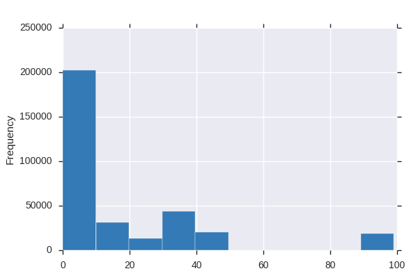

annee_naissance  
Numeric

| Distinct count | 70 |
| --- | --- |
| Unique (%) | 0.0% |
| Missing (%) | 0.1% |
| Missing (n) | 307 |
| Infinite (%) | 0.0% |
| Infinite (n) | 0 |

| Mean | 1983.7 |
| --- | --- |
| Minimum | 1925 |
| Maximum | 1998 |
| Zeros (%) | 0.0% |

Toggle details

Quantile statistics

| Minimum | 1925 |
| --- | --- |
| 5-th percentile | 1971 |
| Q1 | 1980 |
| Median | 1985 |
| Q3 | 1989 |
| 95-th percentile | 1992 |
| Maximum | 1998 |
| Range | 73 |
| Interquartile range | 9 |

Descriptive statistics

| Standard deviation | 6.5635 |
| --- | --- |
| Coef of variation | 0.0033088 |
| Kurtosis | 1.2137 |
| Mean | 1983.7 |
| MAD | 5.2048 |
| Skewness | -0.97464 |
| Sum | 654010000 |
| Variance | 43.08 |
| Memory size | 2.5 MiB |

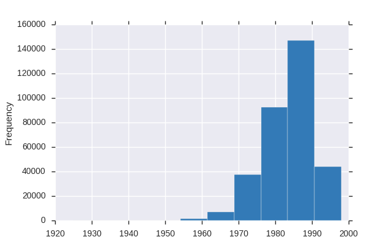

Highly correlated

*This variable is highly correlated with `annee_naissance` and should be ignored for analysis*

| Correlation | 0.99614 |
| --- | --- |

codepostal  
Categorical

| Distinct count | 23746 |
| --- | --- |
| Unique (%) | 7.2% |
| Missing (%) | 0.0% |
| Missing (n) | 0 |

| 1034 | 9723 |
| --- | --- |
| 97411 | 2820 |
| 13001 | 2606 |
| Other values (23743) | 314851 |

Toggle details

| Value | Count | Frequency (%) |  |
| --- | --- | --- | --- |
| 1034 | 9723 | 2.9% |  |
| 97411 | 2820 | 0.9% |  |
| 13001 | 2606 | 0.8% |  |
| 6088 | 2295 | 0.7% |  |
| 31555 | 2275 | 0.7% |  |
| 35238 | 1992 | 0.6% |  |
| 97415 | 1965 | 0.6% |  |
| 20004 | 1932 | 0.6% |  |
| 44109 | 1852 | 0.6% |  |
| 97101 | 1654 | 0.5% |  |
| 34172 | 1629 | 0.5% |  |
| 97422 | 1520 | 0.5% |  |
| 97416 | 1405 | 0.4% |  |
| 1034 | 1402 | 0.4% |  |
| 67482 | 1381 | 0.4% |  |
| 13208 | 1351 | 0.4% |  |
| 87085 | 1194 | 0.4% |  |
| 38185 | 1174 | 0.4% |  |
| 33063 | 1108 | 0.3% |  |
| 97103 | 1083 | 0.3% |  |
| Other values (23726) | 287639 | 87.2% |  |

crm  
Numeric

| Distinct count | 150 |
| --- | --- |
| Unique (%) | 0.0% |
| Missing (%) | 0.0% |
| Missing (n) | 0 |
| Infinite (%) | 0.0% |
| Infinite (n) | 0 |

| Mean | 73.346 |
| --- | --- |
| Minimum | 50 |
| Maximum | 270 |
| Zeros (%) | 0.0% |

Toggle details

Quantile statistics

| Minimum | 50 |
| --- | --- |
| 5-th percentile | 50 |
| Q1 | 50 |
| Median | 68 |
| Q3 | 95 |
| 95-th percentile | 112 |
| Maximum | 270 |
| Range | 220 |
| Interquartile range | 45 |

Descriptive statistics

| Standard deviation | 23.615 |
| --- | --- |
| Coef of variation | 0.32197 |
| Kurtosis | 0.49716 |
| Mean | 73.346 |
| MAD | 20.551 |
| Skewness | 0.81794 |
| Sum | 24204061 |
| Variance | 557.66 |
| Memory size | 2.5 MiB |

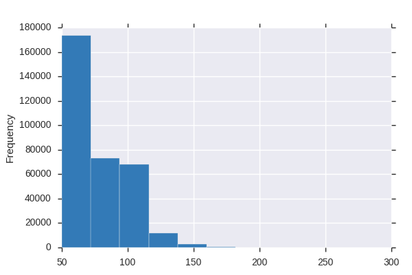

energie_veh  
Categorical

| Distinct count | 6 |
| --- | --- |
| Unique (%) | 0.0% |
| Missing (%) | 0.0% |
| Missing (n) | 0 |

| gazole | 181651 |
| --- | --- |
| essence | 139528 |
| gpl | 7229 |
| Other values (3) | 1592 |

Toggle details

| Value | Count | Frequency (%) |  |
| --- | --- | --- | --- |
| gazole | 181651 | 55.0% |  |
| essence | 139528 | 42.3% |  |
| gpl | 7229 | 2.2% |  |
| hybride essence | 854 | 0.3% |  |
| NR | 430 | 0.1% |  |
| electricite | 308 | 0.1% |  |

id  
Numeric

| Distinct count | 330000 |
| --- | --- |
| Unique (%) | 100.0% |
| Missing (%) | 0.0% |
| Missing (n) | 0 |
| Infinite (%) | 0.0% |
| Infinite (n) | 0 |

| Mean | 165000 |
| --- | --- |
| Minimum | 1 |
| Maximum | 330000 |
| Zeros (%) | 0.0% |

Toggle details

Quantile statistics

| Minimum | 1 |
| --- | --- |
| 5-th percentile | 16501 |
| Q1 | 82501 |
| Median | 165000 |
| Q3 | 247500 |
| 95-th percentile | 313500 |
| Maximum | 330000 |
| Range | 329999 |
| Interquartile range | 165000 |

Descriptive statistics

| Standard deviation | 95263 |
| --- | --- |
| Coef of variation | 0.57735 |
| Kurtosis | -1.2 |
| Mean | 165000 |
| MAD | 82500 |
| Skewness | -1.4357e-15 |
| Sum | 54450165000 |
| Variance | 9075000000 |
| Memory size | 2.5 MiB |

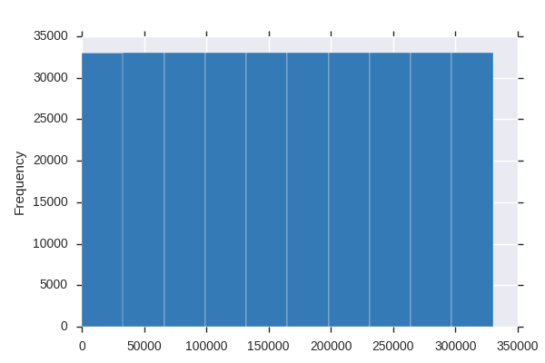

kmage_annuel  
Numeric

| Distinct count | 1263 |
| --- | --- |
| Unique (%) | 0.4% |
| Missing (%) | 0.0% |
| Missing (n) | 0 |
| Infinite (%) | 0.0% |
| Infinite (n) | 0 |

| Mean | 7363.2 |
| --- | --- |
| Minimum | 282 |
| Maximum | 17102 |
| Zeros (%) | 0.0% |

Toggle details

Quantile statistics

| Minimum | 282 |
| --- | --- |
| 5-th percentile | 2863 |
| Q1 | 6387 |
| Median | 6928 |
| Q3 | 7467 |
| 95-th percentile | 12903 |
| Maximum | 17102 |
| Range | 16820 |
| Interquartile range | 1080 |

Descriptive statistics

| Standard deviation | 3086.8 |
| --- | --- |
| Coef of variation | 0.41922 |
| Kurtosis | 0.42163 |
| Mean | 7363.2 |
| MAD | 2135.8 |
| Skewness | 0.70639 |
| Sum | 2429844536 |
| Variance | 9528500 |
| Memory size | 2.5 MiB |

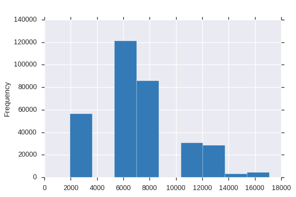

marque  
Categorical

| Distinct count | 157 |
| --- | --- |
| Unique (%) | 0.0% |
| Missing (%) | 0.0% |
| Missing (n) | 0 |

| RENAULT | 78454 |
| --- | --- |
| PEUGEOT | 56408 |
| CITROEN | 37760 |
| Other values (154) | 157378 |

Toggle details

| Value | Count | Frequency (%) |  |
| --- | --- | --- | --- |
| RENAULT | 78454 | 23.8% |  |
| PEUGEOT | 56408 | 17.1% |  |
| CITROEN | 37760 | 11.4% |  |
| VOLKSWAGEN | 21810 | 6.6% |  |
| OPEL | 14857 | 4.5% |  |
| FORD | 14177 | 4.3% |  |
| FIAT | 11942 | 3.6% |  |
| TOYOTA | 11005 | 3.3% |  |
| MERCEDES | 8391 | 2.5% |  |
| NISSAN | 8063 | 2.4% |  |
| BMW | 7142 | 2.2% |  |
| AUDI | 6168 | 1.9% |  |
| SEAT | 5232 | 1.6% |  |
| SUZUKI | 3767 | 1.1% |  |
| HONDA | 3565 | 1.1% |  |
| VOLVO | 3432 | 1.0% |  |
| HYUNDAI | 3064 | 0.9% |  |
| MITSUBISHI | 2904 | 0.9% |  |
| LAND-ROVER | 2703 | 0.8% |  |
| DACIA | 2621 | 0.8% |  |
| Other values (137) | 26535 | 8.0% |  |

profession  
Categorical

| Distinct count | 17 |
| --- | --- |
| Unique (%) | 0.0% |
| Missing (%) | 0.0% |
| Missing (n) | 0 |

| enseignant, formateur, chercheur | 122484 |
| --- | --- |
| agent, employe | 83801 |
| cadre, ingenieur | 33151 |
| Other values (14) | 90564 |

Toggle details

| Value | Count | Frequency (%) |  |
| --- | --- | --- | --- |
| enseignant, formateur, chercheur | 122484 | 37.1% |  |
| agent, employe | 83801 | 25.4% |  |
| cadre, ingenieur | 33151 | 10.0% |  |
| technicien | 16730 | 5.1% |  |
| educateur, animateur, moniteur | 14592 | 4.4% |  |
| profession liberale | 11475 | 3.5% |  |
| ouvrier | 10065 | 3.0% |  |
| demandeur d'emploi | 7298 | 2.2% |  |
| etudiant | 6266 | 1.9% |  |
| artisan | 5580 | 1.7% |  |
| profession de l'information des arts et des spectacles | 5012 | 1.5% |  |
| homme ou femme au foyer | 4963 | 1.5% |  |
| commercant | 2866 | 0.9% |  |
| profession intermediaire de la sante et du travail social | 2485 | 0.8% |  |
| chef d'entreprise | 1534 | 0.5% |  |
| contremaitre, agent de maitrise | 1233 | 0.4% |  |
| agriculteur exploitant | 465 | 0.1% |  |

puis_fiscale  
Numeric

| Distinct count | 51 |
| --- | --- |
| Unique (%) | 0.0% |
| Missing (%) | 0.0% |
| Missing (n) | 0 |
| Infinite (%) | 0.0% |
| Infinite (n) | 0 |

| Mean | 6.8214 |
| --- | --- |
| Minimum | 0 |
| Maximum | 58 |
| Zeros (%) | 0.1% |

Toggle details

Quantile statistics

| Minimum | 0 |
| --- | --- |
| 5-th percentile | 4 |
| Q1 | 5 |
| Median | 6 |
| Q3 | 8 |
| 95-th percentile | 11 |
| Maximum | 58 |
| Range | 58 |
| Interquartile range | 3 |

Descriptive statistics

| Standard deviation | 2.634 |
| --- | --- |
| Coef of variation | 0.38614 |
| Kurtosis | 23.18 |
| Mean | 6.8214 |
| MAD | 1.7402 |
| Skewness | 3.1794 |
| Sum | 2251073 |
| Variance | 6.9381 |
| Memory size | 2.5 MiB |

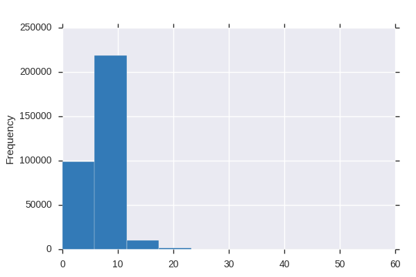

var1  
Numeric

| Distinct count | 71 |
| --- | --- |
| Unique (%) | 0.0% |
| Missing (%) | 0.1% |
| Missing (n) | 307 |
| Infinite (%) | 0.0% |
| Infinite (n) | 0 |

| Mean | 12.949 |
| --- | --- |
| Minimum | -2 |
| Maximum | 72 |
| Zeros (%) | 0.0% |

Toggle details

Quantile statistics

| Minimum | -2 |
| --- | --- |
| 5-th percentile | 5 |
| Q1 | 8 |
| Median | 12 |
| Q3 | 17 |
| 95-th percentile | 25 |
| Maximum | 72 |
| Range | 74 |
| Interquartile range | 9 |

Descriptive statistics

| Standard deviation | 6.5906 |
| --- | --- |
| Coef of variation | 0.50896 |
| Kurtosis | 1.1979 |
| Mean | 12.949 |
| MAD | 5.2153 |
| Skewness | 0.96219 |
| Sum | 4269200 |
| Variance | 43.435 |
| Memory size | 2.5 MiB |

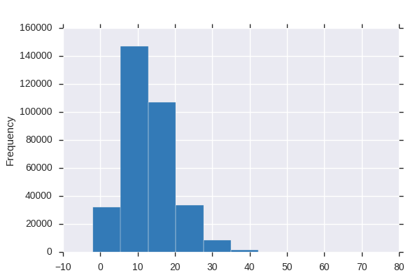

var10  
Numeric

| Distinct count | 213 |
| --- | --- |
| Unique (%) | 0.1% |
| Missing (%) | 0.0% |
| Missing (n) | 0 |
| Infinite (%) | 0.0% |
| Infinite (n) | 0 |

| Mean | 170.54 |
| --- | --- |
| Minimum | 0 |
| Maximum | 548 |
| Zeros (%) | 2.1% |

Toggle details

Quantile statistics

| Minimum | 0 |
| --- | --- |
| 5-th percentile | 132 |
| Q1 | 160 |
| Median | 174 |
| Q3 | 188 |
| 95-th percentile | 210 |
| Maximum | 548 |
| Range | 548 |
| Interquartile range | 28 |

Descriptive statistics

| Standard deviation | 33.78 |
| --- | --- |
| Coef of variation | 0.19807 |
| Kurtosis | 12.049 |
| Mean | 170.54 |
| MAD | 21.088 |
| Skewness | -2.531 |
| Sum | 56279387 |
| Variance | 1141.1 |
| Memory size | 2.5 MiB |

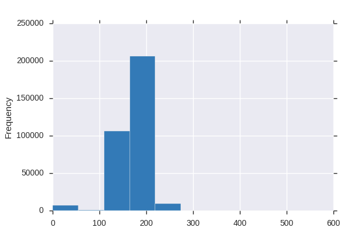

Highly correlated

*This variable is highly correlated with `anc_veh` and should be ignored for analysis*

| Correlation | 0.999 |
| --- | --- |

Highly correlated

*This variable is highly correlated with `kmage_annuel` and should be ignored for analysis*

| Correlation | 0.90886 |
| --- | --- |

var13  
Numeric

| Distinct count | 4 |
| --- | --- |
| Unique (%) | 0.0% |
| Missing (%) | 0.0% |
| Missing (n) | 0 |
| Infinite (%) | 0.0% |
| Infinite (n) | 0 |

| Mean | 4.2256 |
| --- | --- |
| Minimum | 2 |
| Maximum | 5 |
| Zeros (%) | 0.0% |

Toggle details

Quantile statistics

| Minimum | 2 |
| --- | --- |
| 5-th percentile | 2 |
| Q1 | 3 |
| Median | 5 |
| Q3 | 5 |
| 95-th percentile | 5 |
| Maximum | 5 |
| Range | 3 |
| Interquartile range | 2 |

Descriptive statistics

| Standard deviation | 1.0226 |
| --- | --- |
| Coef of variation | 0.242 |
| Kurtosis | -0.84335 |
| Mean | 4.2256 |
| MAD | 0.92269 |
| Skewness | -0.82835 |
| Sum | 1394453 |
| Variance | 1.0457 |
| Memory size | 2.5 MiB |

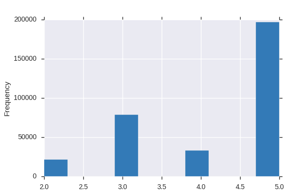

var14  
Categorical

| Distinct count | 8 |
| --- | --- |
| Unique (%) | 0.0% |
| Missing (%) | 0.0% |
| Missing (n) | 0 |

| A | 62469 |
| --- | --- |
| B | 62449 |
| F | 46276 |
| Other values (5) | 158806 |

Toggle details

| Value | Count | Frequency (%) |  |
| --- | --- | --- | --- |
| A | 62469 | 18.9% |  |
| B | 62449 | 18.9% |  |
| F | 46276 | 14.0% |  |
| G | 45126 | 13.7% |  |
| N | 35067 | 10.6% |  |
| C | 34351 | 10.4% |  |
| D | 32757 | 9.9% |  |
| E | 11505 | 3.5% |  |

var15  
Numeric

| Distinct count | 10 |
| --- | --- |
| Unique (%) | 0.0% |
| Missing (%) | 0.0% |
| Missing (n) | 0 |
| Infinite (%) | 0.0% |
| Infinite (n) | 0 |

| Mean | 1.2819 |
| --- | --- |
| Minimum | 0 |
| Maximum | 9 |
| Zeros (%) | 35.2% |

Toggle details

Quantile statistics

| Minimum | 0 |
| --- | --- |
| 5-th percentile | 0 |
| Q1 | 0 |
| Median | 1 |
| Q3 | 2 |
| 95-th percentile | 3 |
| Maximum | 9 |
| Range | 9 |
| Interquartile range | 2 |

Descriptive statistics

| Standard deviation | 1.1735 |
| --- | --- |
| Coef of variation | 0.91543 |
| Kurtosis | 0.41929 |
| Mean | 1.2819 |
| MAD | 1.0088 |
| Skewness | 0.63609 |
| Sum | 423041 |
| Variance | 1.3772 |
| Memory size | 2.5 MiB |

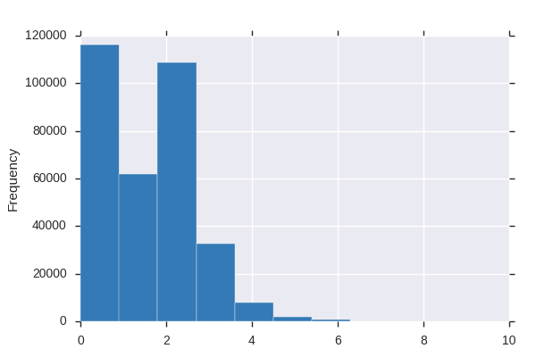

var16  
Categorical

| Distinct count | 7 |
| --- | --- |
| Unique (%) | 0.0% |
| Missing (%) | 0.0% |
| Missing (n) | 0 |

| 1 | 174691 |
| --- | --- |
| 4 | 107415 |
| 5 | 18527 |
| Other values (4) | 29367 |

Toggle details

| Value | Count | Frequency (%) |  |
| --- | --- | --- | --- |
| 1 | 174691 | 52.9% |  |
| 4 | 107415 | 32.6% |  |
| 5 | 18527 | 5.6% |  |
| 3 | 18375 | 5.6% |  |
| 2 | 6773 | 2.1% |  |
| 0 | 3849 | 1.2% |  |
| NR | 370 | 0.1% |  |

var17  
Numeric

| Distinct count | 6 |
| --- | --- |
| Unique (%) | 0.0% |
| Missing (%) | 0.0% |
| Missing (n) | 0 |
| Infinite (%) | 0.0% |
| Infinite (n) | 0 |

| Mean | 1.5863 |
| --- | --- |
| Minimum | 0 |
| Maximum | 5 |
| Zeros (%) | 0.6% |

Toggle details

Quantile statistics

| Minimum | 0 |
| --- | --- |
| 5-th percentile | 1 |
| Q1 | 1 |
| Median | 1 |
| Q3 | 2 |
| 95-th percentile | 4 |
| Maximum | 5 |
| Range | 5 |
| Interquartile range | 1 |

Descriptive statistics

| Standard deviation | 0.96479 |
| --- | --- |
| Coef of variation | 0.60821 |
| Kurtosis | 1.3681 |
| Mean | 1.5863 |
| MAD | 0.76426 |
| Skewness | 1.5648 |
| Sum | 523471 |
| Variance | 0.93083 |
| Memory size | 2.5 MiB |

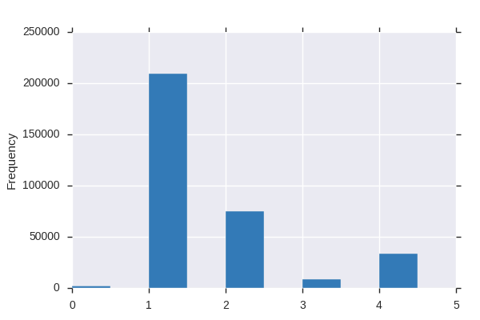

var18  
Numeric

| Distinct count | 46 |
| --- | --- |
| Unique (%) | 0.0% |
| Missing (%) | 0.0% |
| Missing (n) | 0 |
| Infinite (%) | 0.0% |
| Infinite (n) | 0 |

| Mean | 24.194 |
| --- | --- |
| Minimum | 0 |
| Maximum | 45 |
| Zeros (%) | 0.0% |

Toggle details

Quantile statistics

| Minimum | 0 |
| --- | --- |
| 5-th percentile | 19 |
| Q1 | 21 |
| Median | 24 |
| Q3 | 27 |
| 95-th percentile | 33 |
| Maximum | 45 |
| Range | 45 |
| Interquartile range | 6 |

Descriptive statistics

| Standard deviation | 4.6557 |
| --- | --- |
| Coef of variation | 0.19243 |
| Kurtosis | 2.7832 |
| Mean | 24.194 |
| MAD | 3.3989 |
| Skewness | 0.12015 |
| Sum | 7984064 |
| Variance | 21.675 |
| Memory size | 2.5 MiB |

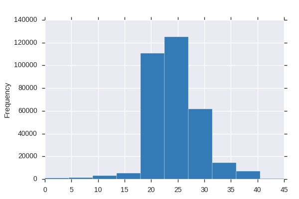

var19  
Numeric

| Distinct count | 29 |
| --- | --- |
| Unique (%) | 0.0% |
| Missing (%) | 0.0% |
| Missing (n) | 0 |
| Infinite (%) | 0.0% |
| Infinite (n) | 0 |

| Mean | 0.54238 |
| --- | --- |
| Minimum | 0 |
| Maximum | 34 |
| Zeros (%) | 69.8% |

Toggle details

Quantile statistics

| Minimum | 0 |
| --- | --- |
| 5-th percentile | 0 |
| Q1 | 0 |
| Median | 0 |
| Q3 | 1 |
| 95-th percentile | 3 |
| Maximum | 34 |
| Range | 34 |
| Interquartile range | 1 |

Descriptive statistics

| Standard deviation | 1.0928 |
| --- | --- |
| Coef of variation | 2.0149 |
| Kurtosis | 39.418 |
| Mean | 0.54238 |
| MAD | 0.75758 |
| Skewness | 4.0638 |
| Sum | 178987 |
| Variance | 1.1943 |
| Memory size | 2.5 MiB |

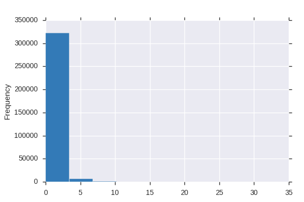

var2  
Numeric

| Distinct count | 6 |
| --- | --- |
| Unique (%) | 0.0% |
| Missing (%) | 0.0% |
| Missing (n) | 0 |
| Infinite (%) | 0.0% |
| Infinite (n) | 0 |

| Mean | 2.9301 |
| --- | --- |
| Minimum | 0 |
| Maximum | 5 |
| Zeros (%) | 1.7% |

Toggle details

Quantile statistics

| Minimum | 0 |
| --- | --- |
| 5-th percentile | 1 |
| Q1 | 2 |
| Median | 3 |
| Q3 | 4 |
| 95-th percentile | 5 |
| Maximum | 5 |
| Range | 5 |
| Interquartile range | 2 |

Descriptive statistics

| Standard deviation | 1.4642 |
| --- | --- |
| Coef of variation | 0.49971 |
| Kurtosis | -1.2534 |
| Mean | 2.9301 |
| MAD | 1.262 |
| Skewness | -0.064484 |
| Sum | 966932 |
| Variance | 2.1439 |
| Memory size | 2.5 MiB |

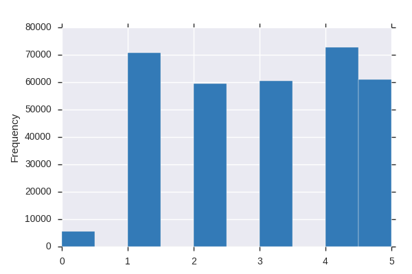

var20  
Numeric

| Distinct count | 2 |
| --- | --- |
| Unique (%) | 0.0% |
| Missing (%) | 0.0% |
| Missing (n) | 0 |
| Infinite (%) | 0.0% |
| Infinite (n) | 0 |

| Mean | 0.53119 |
| --- | --- |
| Minimum | 0 |
| Maximum | 1 |
| Zeros (%) | 46.9% |

Toggle details

Quantile statistics

| Minimum | 0 |
| --- | --- |
| 5-th percentile | 0 |
| Q1 | 0 |
| Median | 1 |
| Q3 | 1 |
| 95-th percentile | 1 |
| Maximum | 1 |
| Range | 1 |
| Interquartile range | 1 |

Descriptive statistics

| Standard deviation | 0.49903 |
| --- | --- |
| Coef of variation | 0.93944 |
| Kurtosis | -1.9844 |
| Mean | 0.53119 |
| MAD | 0.49805 |
| Skewness | -0.12502 |
| Sum | 175294 |
| Variance | 0.24903 |
| Memory size | 2.5 MiB |

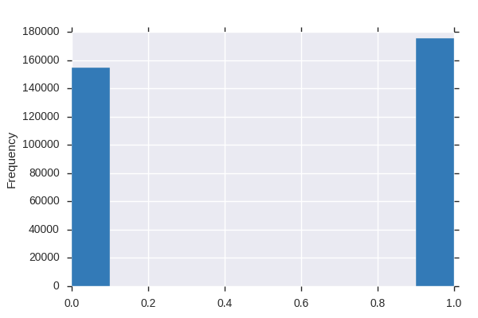

var21  
Numeric

| Distinct count | 2 |
| --- | --- |
| Unique (%) | 0.0% |
| Missing (%) | 0.0% |
| Missing (n) | 0 |
| Infinite (%) | 0.0% |
| Infinite (n) | 0 |

| Mean | 0.9063 |
| --- | --- |
| Minimum | 0 |
| Maximum | 1 |
| Zeros (%) | 9.4% |

Toggle details

Quantile statistics

| Minimum | 0 |
| --- | --- |
| 5-th percentile | 0 |
| Q1 | 1 |
| Median | 1 |
| Q3 | 1 |
| 95-th percentile | 1 |
| Maximum | 1 |
| Range | 1 |
| Interquartile range | 0 |

Descriptive statistics

| Standard deviation | 0.29141 |
| --- | --- |
| Coef of variation | 0.32154 |
| Kurtosis | 5.7759 |
| Mean | 0.9063 |
| MAD | 0.16984 |
| Skewness | -2.7885 |
| Sum | 299079 |
| Variance | 0.084921 |
| Memory size | 2.5 MiB |

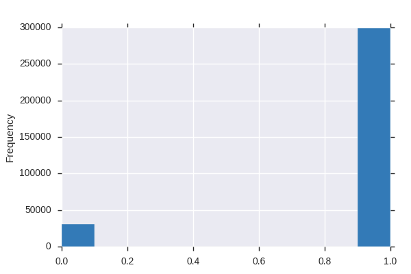

var22  
Numeric

| Distinct count | 25 |
| --- | --- |
| Unique (%) | 0.0% |
| Missing (%) | 0.0% |
| Missing (n) | 0 |
| Infinite (%) | 0.0% |
| Infinite (n) | 0 |

| Mean | 1.1055 |
| --- | --- |
| Minimum | 0 |
| Maximum | 60 |
| Zeros (%) | 38.4% |

Toggle details

Quantile statistics

| Minimum | 0 |
| --- | --- |
| 5-th percentile | 0 |
| Q1 | 0 |
| Median | 1 |
| Q3 | 2 |
| 95-th percentile | 3 |
| Maximum | 60 |
| Range | 60 |
| Interquartile range | 2 |

Descriptive statistics

| Standard deviation | 1.2579 |
| --- | --- |
| Coef of variation | 1.1378 |
| Kurtosis | 68.013 |
| Mean | 1.1055 |
| MAD | 0.91547 |
| Skewness | 3.1668 |
| Sum | 364816 |
| Variance | 1.5822 |
| Memory size | 2.5 MiB |

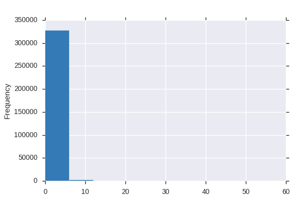

var3  
Numeric

| Distinct count | 2 |
| --- | --- |
| Unique (%) | 0.0% |
| Missing (%) | 0.0% |
| Missing (n) | 0 |
| Infinite (%) | 0.0% |
| Infinite (n) | 0 |

| Mean | 328.91 |
| --- | --- |
| Minimum | 272 |
| Maximum | 372 |
| Zeros (%) | 0.0% |

Toggle details

Quantile statistics

| Minimum | 272 |
| --- | --- |
| 5-th percentile | 272 |
| Q1 | 272 |
| Median | 372 |
| Q3 | 372 |
| 95-th percentile | 372 |
| Maximum | 372 |
| Range | 100 |
| Interquartile range | 100 |

Descriptive statistics

| Standard deviation | 49.52 |
| --- | --- |
| Coef of variation | 0.15056 |
| Kurtosis | -1.9221 |
| Mean | 328.91 |
| MAD | 49.045 |
| Skewness | -0.27909 |
| Sum | 108540400 |
| Variance | 2452.3 |
| Memory size | 2.5 MiB |

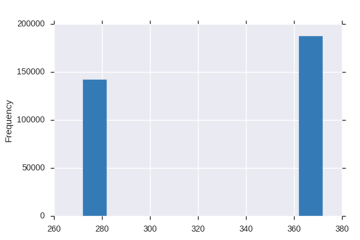

var4  
Numeric

| Distinct count | 10 |
| --- | --- |
| Unique (%) | 0.0% |
| Missing (%) | 0.0% |
| Missing (n) | 0 |
| Infinite (%) | 0.0% |
| Infinite (n) | 0 |

| Mean | 1.2533 |
| --- | --- |
| Minimum | 0 |
| Maximum | 9 |
| Zeros (%) | 46.6% |

Toggle details

Quantile statistics

| Minimum | 0 |
| --- | --- |
| 5-th percentile | 0 |
| Q1 | 0 |
| Median | 1 |
| Q3 | 2 |
| 95-th percentile | 5 |
| Maximum | 9 |
| Range | 9 |
| Interquartile range | 2 |

Descriptive statistics

| Standard deviation | 1.6563 |
| --- | --- |
| Coef of variation | 1.3216 |
| Kurtosis | 3.7254 |
| Mean | 1.2533 |
| MAD | 1.262 |
| Skewness | 1.7909 |
| Sum | 413578 |
| Variance | 2.7434 |
| Memory size | 2.5 MiB |

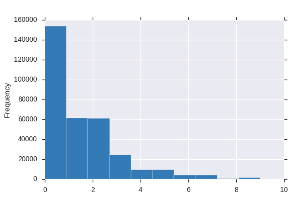

var5  
Numeric

| Distinct count | 2 |
| --- | --- |
| Unique (%) | 0.0% |
| Missing (%) | 0.0% |
| Missing (n) | 0 |
| Infinite (%) | 0.0% |
| Infinite (n) | 0 |

| Mean | 1.4226 |
| --- | --- |
| Minimum | 1 |
| Maximum | 2 |
| Zeros (%) | 0.0% |

Toggle details

Quantile statistics

| Minimum | 1 |
| --- | --- |
| 5-th percentile | 1 |
| Q1 | 1 |
| Median | 1 |
| Q3 | 2 |
| 95-th percentile | 2 |
| Maximum | 2 |
| Range | 1 |
| Interquartile range | 1 |

Descriptive statistics

| Standard deviation | 0.49397 |
| --- | --- |
| Coef of variation | 0.34724 |
| Kurtosis | -1.9018 |
| Mean | 1.4226 |
| MAD | 0.48801 |
| Skewness | 0.31347 |
| Sum | 469451 |
| Variance | 0.24401 |
| Memory size | 2.5 MiB |

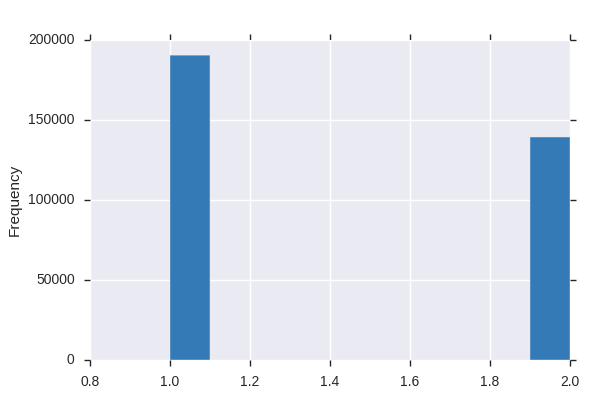

var6  
Categorical

| Distinct count | 5 |
| --- | --- |
| Unique (%) | 0.0% |
| Missing (%) | 0.0% |
| Missing (n) | 0 |

| B | 127920 |
| --- | --- |
| A | 98693 |
| C | 83813 |
| Other values (2) | 19574 |

Toggle details

| Value | Count | Frequency (%) |  |
| --- | --- | --- | --- |
| B | 127920 | 38.8% |  |
| A | 98693 | 29.9% |  |
| C | 83813 | 25.4% |  |
| D | 18978 | 5.8% |  |
| N | 596 | 0.2% |  |

var7  
Categorical

| Distinct count | 19 |
| --- | --- |
| Unique (%) | 0.0% |
| Missing (%) | 0.0% |
| Missing (n) | 0 |

| 1 | 169758 |
| --- | --- |
| 3 | 35802 |
| 11 | 23368 |
| Other values (16) | 101072 |

Toggle details

| Value | Count | Frequency (%) |  |
| --- | --- | --- | --- |
| 1 | 169758 | 51.4% |  |
| 3 | 35802 | 10.8% |  |
| 11 | 23368 | 7.1% |  |
| 10 | 23198 | 7.0% |  |
| 4 | 15106 | 4.6% |  |
| 5 | 13384 | 4.1% |  |
| 7 | 9921 | 3.0% |  |
| 8 | 9189 | 2.8% |  |
| 20 | 9099 | 2.8% |  |
| 2 | 8349 | 2.5% |  |
| 6 | 5007 | 1.5% |  |
| 12 | 2537 | 0.8% |  |
| 14 | 2253 | 0.7% |  |
| 13 | 1552 | 0.5% |  |
| 9 | 855 | 0.3% |  |
| 0 | 309 | 0.1% |  |
| NR | 307 | 0.1% |  |
| 50 | 5 | 0.0% |  |
| 30 | 1 | 0.0% |  |

var8  
Categorical

| Distinct count | 24 |
| --- | --- |
| Unique (%) | 0.0% |
| Missing (%) | 0.0% |
| Missing (n) | 0 |

| M1 | 101090 |
| --- | --- |
| B2 | 74439 |
| M2 | 58033 |
| Other values (21) | 96438 |

Toggle details

| Value | Count | Frequency (%) |  |
| --- | --- | --- | --- |
| M1 | 101090 | 30.6% |  |
| B2 | 74439 | 22.6% |  |
| M2 | 58033 | 17.6% |  |
| H1 | 25922 | 7.9% |  |
| B1 | 25170 | 7.6% |  |
| T3 | 8946 | 2.7% |  |
| T2 | 7938 | 2.4% |  |
| F | 5915 | 1.8% |  |
| K | 4176 | 1.3% |  |
| T1 | 3130 | 0.9% |  |
| T4 | 3020 | 0.9% |  |
| MC | 2292 | 0.7% |  |
| K2 | 2273 | 0.7% |  |
| PU | 1802 | 0.5% |  |
| P3 | 1755 | 0.5% |  |
| VA | 1559 | 0.5% |  |
| H2 | 1490 | 0.5% |  |
| NR | 604 | 0.2% |  |
| TU | 407 | 0.1% |  |
| P1 | 16 | 0.0% |  |
| Other values (4) | 23 | 0.0% |  |

var9  
Numeric

| Distinct count | 335 |
| --- | --- |
| Unique (%) | 0.1% |
| Missing (%) | 0.0% |
| Missing (n) | 0 |
| Infinite (%) | 0.0% |
| Infinite (n) | 0 |

| Mean | 97.71 |
| --- | --- |
| Minimum | 0 |
| Maximum | 620 |
| Zeros (%) | 0.4% |

Toggle details

Quantile statistics

| Minimum | 0 |
| --- | --- |
| 5-th percentile | 55 |
| Q1 | 71 |
| Median | 90 |
| Q3 | 115 |
| 95-th percentile | 163 |
| Maximum | 620 |
| Range | 620 |
| Interquartile range | 44 |

Descriptive statistics

| Standard deviation | 37.172 |
| --- | --- |
| Coef of variation | 0.38043 |
| Kurtosis | 8.9039 |
| Mean | 97.71 |
| MAD | 27.063 |
| Skewness | 1.7832 |
| Sum | 32244413 |
| Variance | 1381.7 |
| Memory size | 2.5 MiB |

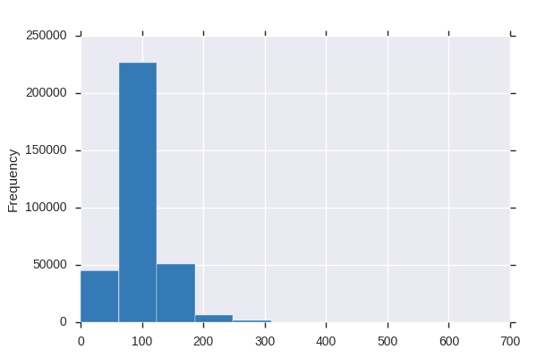

# Sample

| id | annee_naissance | annee_permis | marque | puis_fiscale | anc_veh | codepostal | energie_veh | kmage_annuel | crm | profession | var1 | var2 | var3 | var4 | var5 | var6 | var7 | var8 | var9 | var10 | var11 | var12 | var13 | var14 | var15 | var16 | var17 | var18 | var19 | … |
| --- | --- | --- | --- | --- | --- | --- | --- | --- | --- | --- | --- | --- | --- | --- | --- | --- | --- | --- | --- | --- | --- | --- | --- | --- | --- | --- | --- | --- | --- | --- |
| 1 | 1986.0 | 2006.0 | RENAULT | 4 | 1 | 1034 | gpl | 2924 | 68 | enseignant, formateur, chercheur | 10.0 | 1 | 372 | 0 | 1 | A | 1 | B1 | 60 | 155 | 1 | 855 | 3 | N | 1 | 1 | 1 | 27 | 0 | … |
| 2 | 1986.0 | 2006.0 | RENAULT | 8 | 2 | 1034 | gpl | 11580 | 50 | enseignant, formateur, chercheur | 10.0 | 1 | 372 | 0 | 1 | B | 7 | H1 | 115 | 175 | 2 | 1490 | 5 | N | 2 | 1 | 1 | 28 | 0 | … |
| 3 | 1982.0 | 2001.0 | RENAULT | 7 | 2 | 1034 | gpl | 7149 | 95 | enseignant, formateur, chercheur | 15.0 | 2 | 372 | 0 | 2 | C | 10 | M1 | 90 | 170 | 2 | 1278 | 5 | N | 3 | 1 | 1 | 29 | 0 | … |
| 4 | 1987.0 | 2006.0 | DACIA | 5 | 2 | 1034 | gpl | 6526 | 100 | enseignant, formateur, chercheur | 10.0 | 4 | 372 | 0 | 1 | A | 1 | B2 | 75 | 161 | 2 | 1065 | 5 | N | 3 | 1 | 1 | 29 | 0 | … |
| 5 | 1994.0 | 2013.0 | CITROEN | 4 | 2 | 1034 | gpl | 2872 | 50 | cadre, ingenieur | 3.0 | 2 | 372 | 2 | 2 | B | 1 | B2 | 60 | 162 | 2 | 825 | 5 | N | 2 | 1 | 4 | 26 | 0 | … |